# Analysis of Hr indicators as predictor of employeers left

Giusti Elena,Sarah Wong..

### Human Resources Analytics

## Why are our best and most experienced employees leaving prematurely?

This is a dataset that includes 14999 observation of single employees  
Fields in the dataset include:

Employee satisfaction level  
Last evaluation  
Number of projects  
Average monthly hours  
Time spent at the company  
Whether they have had a work accident  
Whether they have had a promotion in the last 5 years  
Department  
Salary  
Whether the employee has left

# The objectives of the project are the followings

Which of those factors influence the employeers leaving?  
Who will leave next?

# The project is divided in the following step

Step 1) Analyse actual state of the company HR indicators - Clean the data - Describe the data  
Step 2) Analyse correlation and main factor definining HR indicators -Correlationa analysis -Factor reduction  
Step 3) Build a regression model to estimate who will be more likely to leave -Simple regression model -Randomtree model

## >Step 1)Analyse actual state of the company HR indicator

```r
myData <- read.csv(file = "DATA/HR_comma_sep.csv", header = TRUE, sep=",")
View(myData, header=TRUE)
colnames(myData)

print(myData[1:10])
```

[output not shown]

Looking at data we can make the following assumptions related the nature of the 10 variables

satisfaction_level: A numeric indictor, presumably filled out by the employee.  
last_evaluation: A numeric indicator, presumably filled in by the employee’s manager.  
number_project: A integer - perhaps the number of projects the employee has worked on.  
average_monthly_hours: The number of hours they work in the month time_spend_company: An integer value, perhaps years of service.  
Work_accident: Looks like a boolean value, probably whether(1) or not(0) they had an accident.  
left: Looks like a boolean value, leave (1), not leave(0) promoted_last_5years: Looks like a boolean value, promoted(1), not promoted(0)  
sales: Is a categorical variable assessing the department (sales,technical…)  
salary: Looks like a 3-level salary score (low, medium, high)

```r
#We assess if there are any missing data and perform basic descriptive statistic on the data

summary(myData)
```

```
##  satisfaction_level last_evaluation  number_project  average_montly_hours
##  Min.   :0.0900     Min.   :0.3600   Min.   :2.000   Min.   : 96.0
##  1st Qu.:0.4400     1st Qu.:0.5600   1st Qu.:3.000   1st Qu.:156.0
##  Median :0.6400     Median :0.7200   Median :4.000   Median :200.0
##  Mean   :0.6128     Mean   :0.7161   Mean   :3.803   Mean   :201.1
##  3rd Qu.:0.8200     3rd Qu.:0.8700   3rd Qu.:5.000   3rd Qu.:245.0
##  Max.   :1.0000     Max.   :1.0000   Max.   :7.000   Max.   :310.0
##
##  time_spend_company Work_accident         left
##  Min.   : 2.000     Min.   :0.0000   Min.   :0.0000
##  1st Qu.: 3.000     1st Qu.:0.0000   1st Qu.:0.0000
##  Median : 3.000     Median :0.0000   Median :0.0000
##  Mean   : 3.498     Mean   :0.1446   Mean   :0.2381
##  3rd Qu.: 4.000     3rd Qu.:0.0000   3rd Qu.:0.0000
##  Max.   :10.000     Max.   :1.0000   Max.   :1.0000
##
##  promotion_last_5years         sales         salary
##  Min.   :0.00000       sales      :4140   high  :1237
##  1st Qu.:0.00000       technical  :2720   low   :7316
##  Median :0.00000       support    :2229   medium:6446
##  Mean   :0.02127       IT         :1227
##  3rd Qu.:0.00000       product_mng: 902
##  Max.   :1.00000       marketing  : 858
##                        (Other)    :2923
```

From basic statistical analysis we see that the overall satisfaction of the company is really low around 63% and that approximately 24% of the employees left. This brings us to the following step we would like therefore to understand bettwe who are the employees that are leaving

# Who is leaving

We will start our analysis looking more deeply to a subset of employers that are leaving

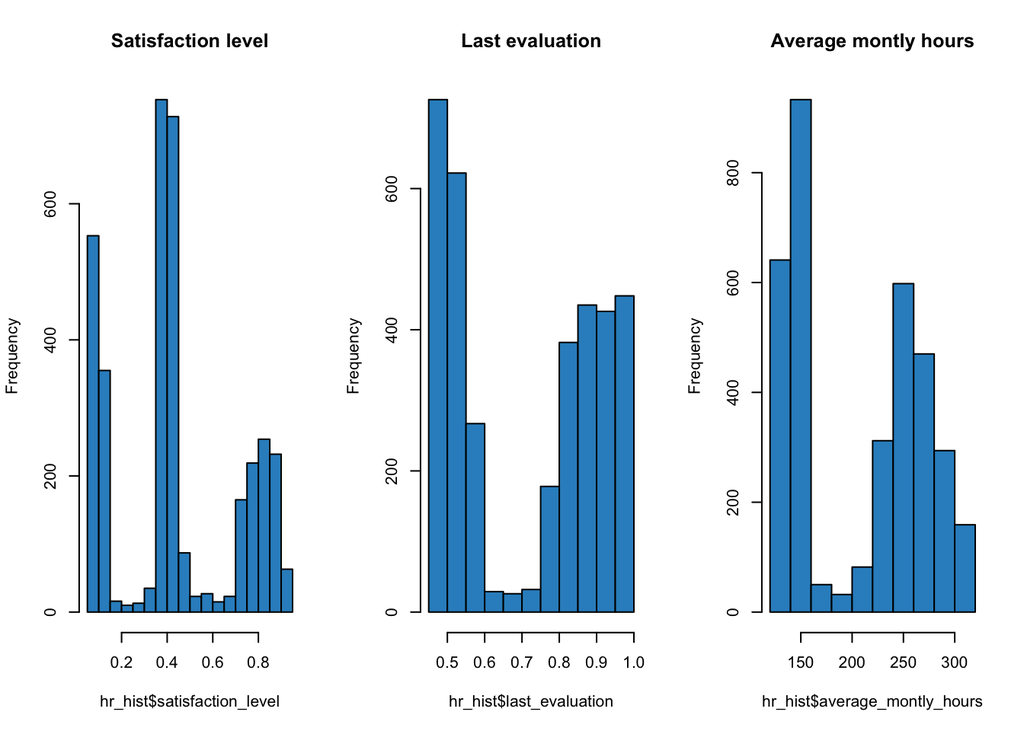

```r
hr_hist <- filter(myData,left==1)
par(mfrow=c(1,3))
hist(hr_hist$satisfaction_level,col="#3090C7", main = "Satisfaction level")
hist(hr_hist$last_evaluation,col="#3090C7", main = "Last evaluation")
hist(hr_hist$average_montly_hours,col="#3090C7", main = "Average montly hours")
```

From the previous histograms we can colcude that not only employers with low satisfaction level and bad evaluation are leaving.

Looking at data it seems that none of the distribution is normal but show strong polarization:

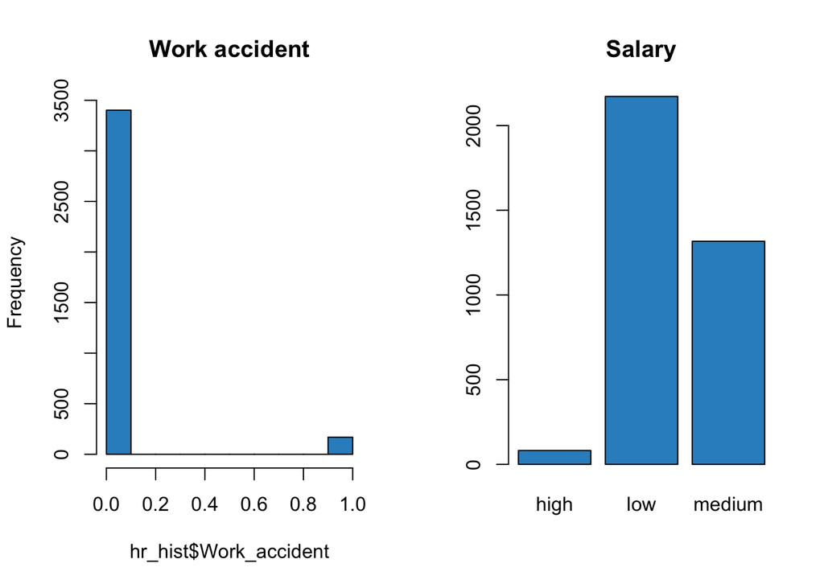

```r
par(mfrow=c(1,2))
hist(hr_hist$Work_accident,col="#3090C7", main = "Work accident")
plot(hr_hist$salary,col="#3090C7", main = "Salary")
```

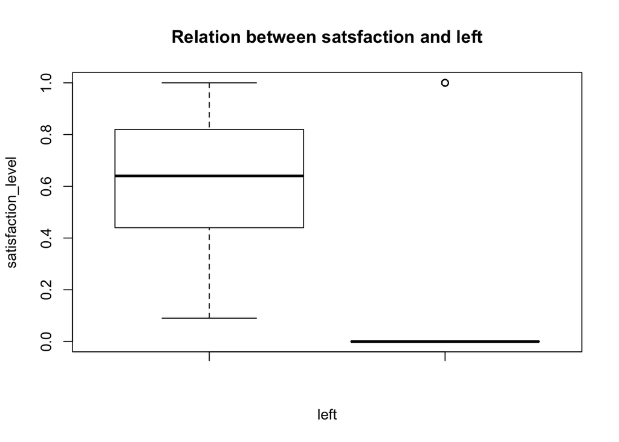

```r
boxplot(myData[,1],myData[,7], main="Relation between satsfaction and left",xlab="left",ylab="satisfaction_level")
```